# Whatsapp Chat Analysis in Python

### Introduction

Whatsapp is a heavily used IM medium, especially by college students. **Whatsapp Groups** provide an easy medium to share data and news quickly. Many interesting insights might pop up, from a simple analyis on these chats.

Whatsapp includes a feature to email the history of a chat to a person. This feature can be exploited to do an analysis on the chats. This analysis notebook gives various insights that can be derived from the chat history of a Whatsapp group.

*The following analysis was done on a college class group of 88 members, history dated from 28/08/16 to 03/06/17*

## Step 1: Import all necessary modules

For the analysis, we will be using the following modules.

1. Numpy and Pandas library are used to provide the data structres to store data and perform operations on it.
2. Matplotlib and seaborn help with displaying graphs.
3. The in-built module re is used for cleaning up the data.

```python
import re

# plot the graphs inside the notebook
%matplotlib inline
import matplotlib.pyplot as plt
import seaborn as sns

import numpy as np
import pandas as pd

from datetime import datetime
from IPython.display import HTML, display #To display data in HTML table format

print ("Import Successful")
```

```
Import Successful
```

## Step 2: Read Data File

The "Email Chat" feature of whatsapp allows an user to share his chat history to people via email. The chat data is shared in the form of a plain-text file.

Let us load the file into python, and have a look at the first 15 lines of the file.

```python
print ("\n~File read Initiated~\n")

file = open("D10chats.txt",
            "r",             #read mode
            encoding="utf-8" #to support whatsapp emojis
           )

for line in list(file)[:15]:
    print(line, end='')

# seek back to the start of the file
file.seek(0)

print ("\n~File read Successful~")
```

```
~File read Initiated~

28/08/16, 7:59 PM - Suraj(VESIT): Guys!
Commencement of 'paper elims' will be either in breaks or after 2:45.
So b ready!
And there should be teams of exactly 3 members each
28/08/16, 8:01 PM - Adheesh( VESIT): 😂😂
28/08/16, 8:02 PM - Onkar Singh(VESIT): Just get the gcc and path add karde
28/08/16, 8:02 PM - Onkar Singh(VESIT): Pura naya codeblocks download karne ki jarurat nhi
28/08/16, 8:22 PM - Aishwarya B(VESIT): Paper elims?
28/08/16, 8:22 PM - Onkar Singh(VESIT): Nook ?
28/08/16, 8:22 PM - Utsav(VESIT): Yeah there will be 15 questions
28/08/16, 8:23 PM - Utsav(VESIT): In the paper elims
28/08/16, 8:23 PM - Saish M(VESIT): Duration?
28/08/16, 8:23 PM - Utsav(VESIT): Not confirmed yet
28/08/16, 8:23 PM - Aishwarya B(VESIT): Which subject?
28/08/16, 8:23 PM - Utsav(VESIT): But it will be short

~File read Successful~
```

#### Insights

Having a look at the file, we can see that the chats follow a format. We need to extract the data from that format somehow.

Also, we see that **not all lines follow the format**. Multiline messages are broken by new-line characters. This needs to be taken care of first. So we would be first bringing down the multiline messages to a single line, so that all the lines inthe file follow a standard format. This can be easily done with the help of Regex (Regular Expressions), which brings us to our next step.

## Step 3: Data Wrangling (using regex)

Cleaning up the raw data is always a crucial part of any analysis as it decides what insights the data might lead you to. Removing out the unnecessary parts will bring about a significant improvement on the analysis.

Here, we use the python RE module ([More about python RE module](https://docs.python.org/3/library/re.html)) to slice the different components from the text format.

Firstly, we define our Regular Expressions and compile them, so that they can be used later.

```python
import re

# messages are matched using this re
message = re.compile(r'(\d{2}/\d{2}/\d{2,4}),\s(\d{1,2}:\d{2}\s[AaPp][Mm])\s-\s([^:]{1,30}):\s(.*)')

# notification messages such as changing the group name, icon are matched using this re
other = re.compile(
    r'(\d{2}/\d{2}/\d{2,4}),\s(\d{1,2}:\d{2}\s[AaPp][Mm])\s-\s.+')
```

### Multiline to single line

The following piece of code, as the title suggests, converts the multiline messages to a single line and stores the data in a new Cleaned file.

```python
file.seek(0)

fileWrite = open("D10ChatsCleaned.txt", "w", encoding="utf-8")

data = file.readlines()

for i, line in enumerate(data):
    m = message.match(line)
    n = other.match(line)
    if m or n:
        data[i] = "\n"+line.rstrip()
    else:
        data[i] = line.rstrip()


fileWrite.writelines(data)

fileWrite.close()
```

### Text to Table

The cleaned text data can now be easily converted to tabular matrix format, using the same Regular Expressions that we used above. A (n X 4) matrix is created, which now contains 4 separate data columns; Date, Time, Sender and Message.

```python
messages = []

fileCleaned = open("D10ChatsCleaned.txt", "r", encoding="utf-8")

for line in list(fileCleaned):
    m = message.match(line)
    if m:
        messages.append(list(m.groups()))

fileCleaned.close()
```

## Step 4: View Data

Finally, the matrix can now be converted into a dataframe, so that analysis can be started. Before starting the analysis, let us look at the first 5 rows of our data, just to be sure that everything was done right.

```python
df = pd.DataFrame(messages, columns = ["Date", "Time", "Sender", "Message"])
df.head()
```

|  | Date | Time | Sender | Message |
| --- | --- | --- | --- | --- |
| 0 | 28/08/16 | 7:59 PM | Suraj(VESIT) | Guys!Commencement of 'paper elims' will be eit... |
| 1 | 28/08/16 | 8:01 PM | Adheesh( VESIT) | 😂😂 |
| 2 | 28/08/16 | 8:02 PM | Onkar Singh(VESIT) | Just get the gcc and path add karde |
| 3 | 28/08/16 | 8:02 PM | Onkar Singh(VESIT) | Pura naya codeblocks download karne ki jarurat... |
| 4 | 28/08/16 | 8:22 PM | Aishwarya B(VESIT) | Paper elims? |

```python
df.info()
```

```
<class 'pandas.core.frame.DataFrame'>
RangeIndex: 39491 entries, 0 to 39490
Data columns (total 4 columns):
Date       39491 non-null object
Time       39491 non-null object
Sender     39491 non-null object
Message    39491 non-null object
dtypes: object(4)
memory usage: 617.1+ KB
```

By info() method, we can see that all the data is currently still in string object format. Later, we would have to convert date and time from string format to DateTime format, so that analysis becomes easier.

## Step 5: Analysis

### Step 5.1: Heads up Analysis

A lot of insight can be obtained straightaway using the describe() method.

```python
df.describe()
```

|  | Date | Time | Sender | Message |
| --- | --- | --- | --- | --- |
| count | 39491 | 39491 | 39491 | 39491 |
| unique | 279 | 1302 | 88 | 26716 |
| top | 23/02/17 | 11:04 PM | Murli😎 | <Media omitted> |
| freq | 1913 | 139 | 4154 | 2078 |

#### Insights

##### 1. Total Messages - 39491

Count shows that the total number of messages in the group sent during the time period is 39491.

The count of all columns is equal. It tells us that the **data is complete**, and there are no empty data cells.

##### 2. Time Span - 279 Days

The number of unique rows in the date Column provides us with the time span of the chat history that we are analysing on.

##### 3. Average messages sent per day - 141.55 messages/day

(Total messages / time span) gives us the average messages sent per day

##### 3. Highest number of messages sent on - 23.02.17 (1913 Messages)

The top field in Date tells us that this date was repeated maximum number of times, i.e. maximum number of messages were sent on that day. The frequency tells the number of times that date was repeated, which gives us the number of messages that were sent in that day.

Now that we know about it, wouldn't it be intersting to know what that day's chats were about? :p

##### 4. Active Group Members - 88

Unique count of Sender gives us the number of Active group members in the group.

##### 5. The Rank 1 - Murli (4154 messages)

Member who has sent the highest number of messages can be obtained from top of sender. The number of messages sent by the member can be retrieved from the freq field.

##### 6. Media Shared - 2078 files

A description on the messages column reveals that \<media ommited> was the top message sent, i.e. messages having media files. A frequency of the message can say about the total number of media files shared.

### Step 5.2: Individual Message Count

Often it is interesting to know how active a person is in the group. We have already seen the most active member, but it would be interesting to see how many messages were sent by each individual.

For readability, only the top 10 members are displayed.

```python
pd.crosstab(index=df["Sender"], columns="Message Count").sort_values("Message Count", ascending = False).head(10)
```

| col_0 Sender | Message Count |
| --- | --- |
| Murli😎 | 4154 |
| Vishal | 2649 |
| Tyson | 2616 |
| Harsh Jain (VESIT) | 2498 |
| Arvind N(VESIT) | 2479 |
| Onkar Singh(VESIT) | 2399 |
| Sagar(VESIT) | 2037 |
| Shravan | 1595 |
| Sidhant(VESIT) | 1563 |
| Mishall (VESIT) | 1436 |

### Step 5.3: When is the group active (Time of the day)

Another analysis we would like to do is during what time of the day are most of the messages sent. This can give various insights about the group.

Before going into the analysis, we convert the time fields, that are in string format to float values.

Float values can represent the time in 24 hour format. Eg. 0.12 signifies 12:12 AM and 12.45 denotes 12:45 PM

```python
def strTimeToFloat(time):
    timeF = float(time[:-3].replace(":","."))
    if time[-2] == 'P' or time[-2] == 'p':
        if int(timeF) != 12:
            timeF+=12
    elif int(timeF) == 12:
        timeF -= 12
    return timeF
```

Here, we calculate the number of messages in each minute and sort it accorting to the time of the day (12 AM to 11.59 PM). We plot the data as a line plot between time and the number of messages sent.

```python
sTime = df["Time"].apply(strTimeToFloat)
sTime.value_counts().sort_index().head()
```

```
0.00    118
0.01    118
0.02    120
0.03     92
0.04     86
Name: Time, dtype: int64
```

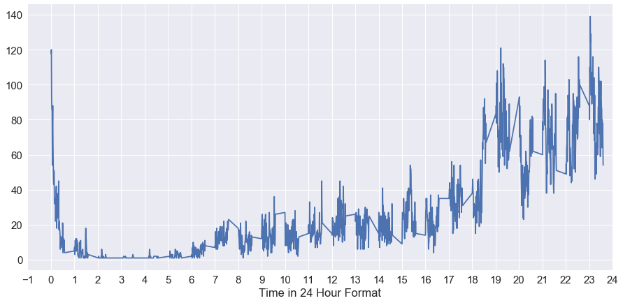

```python
sns.set(font_scale = 1.5)

plt.figure(figsize=(15,7))
# sns.distplot(sTime, hist=True, axlabel="Time in 24 Hour format", label="Kernel Density Estimate")

sTime.value_counts().sort_index().plot(kind='line', xticks = np.arange(-1, 25, 1.0) )
plt.xlabel("Time in 24 Hour Format")
```

#### Insights

##### 1. Peak at 12:00 AM - Birthday Wishes

There is a peak of messages at 12:00 AM. It is intersting to know the reason for this. Going through the chats, it is found that members send birthday wishes at 12:00 AM, which gives a reasoning for the peak to occur.

##### 2. No activity from 2 AM to 5 AM

##### 3. Medium activity during college hours

##### 4. Increasing activity during evening hours and Maximum activity in the night.

### Step 5.4: When is the group active ( Monthy Report)

For this analysis, we would need the date field. So we first convert the date string to DateTime format. After the conversion we plot a bar plot showing the messages sent every month.

```python
def dateConv(dateString):
    date = datetime.strptime(dateString, "%d/%m/%y")
    return date
df["Date"] = df["Date"].apply(dateConv)
```

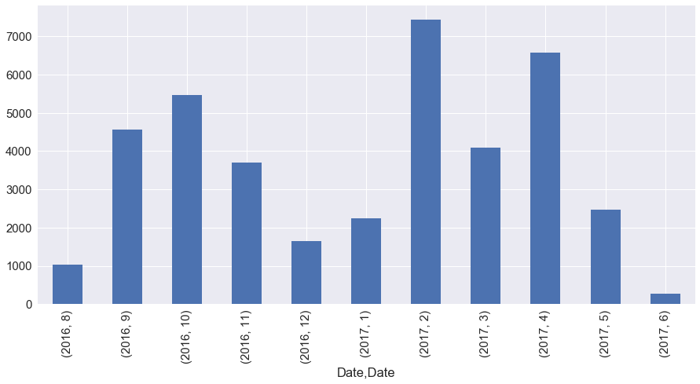

```python
plt.figure(figsize=(15,7))

df.groupby([df["Date"].dt.year, df["Date"].dt.month]).count()["Date"].plot(kind="bar")
```

#### Insights

##### 1. Low activity in December and January

These months have low activity. It can be reasonable as it is generally the exam and vacation period.

Note:- We ignore the activiy of August 2016 and June 2017 as these months do not have data for the complete month.

##### 2. Highest activity in February

High activity in this month may be due to college fests and cultural activites that went on during this period.

### Alternate Plot

This plot is a line plot of daily analysis of the messages.

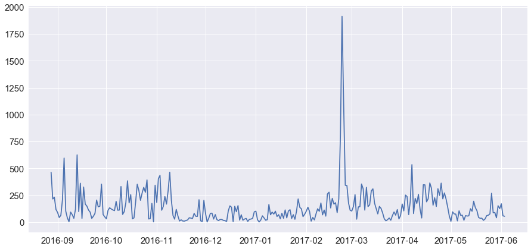

```python
plt.figure(figsize=(15,7))

df.groupby("Date")["Date"].head(1)

plt.plot(df.groupby("Date")["Date"].head(1),df.groupby("Date").count()["Time"])
```

### Step 5.5: Characters per message

So far, we have done analysis on date and time. Now, we move on to the messages. We group the messages by the sender, and try to gain insight on the characters sent by each person.

We calculate the total number of characters sent by each person. This leads us to an interesting insight, what is the average length of message of each member. This can tell us if a person likes to keep his/her messages short or long.

For readability, only 10 members are displayed.

```python
charPerMessage = []

for name, group in df["Message"].groupby(df["Sender"]):
    totLen = 0
    for message in group:
        totLen += len(message)
    charPerMessage.append([name, totLen, round(totLen/len(group), 2)])

display(HTML(
'''<table>
        <th>Name</th><th>Total</th><th>Average</th>
            <tr>{}</tr>
    </table>'''.format(
    '</tr><tr>'.join(
        '<td>{}</td>'.format('</td><td>'.join(str(_) for _ in row)) for row in charPerMessage[:10])
    )
))
```

| Aarti B(VESIT) | 1831 | 22.06 |
| --- | --- | --- |
| Abhishek(Tyson)(VESIT) | 9847 | 31.66 |
| Abid I(VESIT) | 15504 | 61.04 |
| Adheesh( VESIT) | 24283 | 31.05 |
| Aditya B(VESIT) | 1608 | 100.5 |
| Aishwarya B(VESIT) | 20016 | 26.06 |
| Aman Gupta(VESIT) | 456 | 24.0 |
| Anchal L | 8528 | 44.65 |
| Anuja C(VESIT) | 27629 | 77.39 |
| Arvind N(VESIT) | 61495 | 24.81 |

## Conclusion

A simple analysis on whatsapp chat gave us a lot of insights. It can help in help is scientific studies such as the effect of Whatsapp on people. It can tell us about the lifestyle of people.

Further analysis can be done using Natural Language processing and gaining information on the types of messages sent by people.